# Flight data

christianbomholt

September 24, 2018

# Airline Service Quality Performance 234 (On-Time performance data)

This data has been reported by U.S. certificated air carriers so that information on the air carriers’ quality of service can be made available to consumers of air transportation.

Carriers within 1% or more of the total domestic scheduled service passenger revenues are required to report data for flights involving any airport in the 48 contiguous states accounting for 1% or more of the domestic scheduled service passenger enplanements. The regulation also provides for the voluntary reporting of a carrier’s entire domestic system and voluntary reporting by other carriers. Some of the data elements included are departure, arrival, and elapsed flight times as shown by the Official Airline Guide; the carrier’s computer reservation system and the carrier’s actual performance; and selected differences among the three sources, such as delay and elapsed time difference.

## Import data

```r
library(ggplot2)
library(dplyr)
library(DT)
```

```r
flightCSV <- "../data/flight_data/2000.csv"

flightDF <- read.csv(flightCSV,nrows = 1e5)[,-1]
datatable(head(flightDF, 10), options = list('t'))
```

|  | Year | Month | DayofMonth | DayOfWeek | DepTime | CRSDepTime | ArrTime | CRSArrTime | UniqueCarrier | FlightNum | TailNum | ActualElapsedTime | CRSElapsedTime | AirTime | ArrDelay | DepDelay | Origin | Dest | Distance | TaxiIn | TaxiOut | Cancelled | CancellationCode | Diverted | CarrierDelay | WeatherDelay | NASDelay | SecurityDelay | LateAircraftDelay |
| --- | --- | --- | --- | --- | --- | --- | --- | --- | --- | --- | --- | --- | --- | --- | --- | --- | --- | --- | --- | --- | --- | --- | --- | --- | --- | --- | --- | --- | --- |
| 1 | 2000 | 1 | 1 | 6 | 842 | 846 | 1057 | 1101 | HP | 609 | N158AW | 255 | 255 | 244 | -4 | -4 | ATL | PHX | 1587 | 3 | 8 | 0 |  | 0 |  |  |  |  |  |
| 2 | 2000 | 1 | 3 | 1 | 844 | 846 | 1121 | 1101 | HP | 609 | N803AW | 277 | 255 | 244 | 20 | -2 | ATL | PHX | 1587 | 6 | 27 | 0 |  | 0 |  |  |  |  |  |
| 3 | 2000 | 1 | 9 | 7 | 2008 | 1932 | 2221 | 2153 | HP | 613 | N168AW | 253 | 261 | 237 | 28 | 36 | ATL | PHX | 1587 | 4 | 12 | 0 |  | 0 |  |  |  |  |  |
| 4 | 2000 | 1 | 17 | 1 | 1943 | 1932 | 2148 | 2153 | HP | 613 | N150AW | 245 | 261 | 222 | -5 | 11 | ATL | PHX | 1587 | 6 | 17 | 0 |  | 0 |  |  |  |  |  |
| 5 | 2000 | 1 | 19 | 3 | 1935 | 1932 | 2210 | 2153 | HP | 613 | N168AW | 275 | 261 | 243 | 17 | 3 | ATL | PHX | 1587 | 7 | 25 | 0 |  | 0 |  |  |  |  |  |
| 6 | 2000 | 1 | 20 | 4 | 1951 | 1932 | 2214 | 2153 | HP | 613 | N168AW | 263 | 261 | 227 | 21 | 19 | ATL | PHX | 1587 | 4 | 32 | 0 |  | 0 |  |  |  |  |  |
| 7 | 2000 | 1 | 6 | 4 | 826 | 826 | 1057 | 1039 | HP | 2027 | N633AW | 271 | 253 | 249 | 18 | 0 | ATL | PHX | 1587 | 4 | 18 | 0 |  | 0 |  |  |  |  |  |
| 8 | 2000 | 1 | 10 | 1 | 935 | 826 | 1150 | 1039 | HP | 2027 | N633AW | 255 | 253 | 239 | 71 | 69 | ATL | PHX | 1587 | 4 | 12 | 0 |  | 0 |  |  |  |  |  |
| 9 | 2000 | 1 | 20 | 4 | 826 | 826 | 1058 | 1039 | HP | 2027 | N641AW | 272 | 253 | 236 | 19 | 0 | ATL | PHX | 1587 | 4 | 32 | 0 |  | 0 |  |  |  |  |  |
| 10 | 2000 | 1 | 15 | 6 | 838 | 826 | 1050 | 1039 | HP | 2836 | N801AW | 252 | 253 | 225 | 11 | 12 | ATL | PHX | 1587 | 5 | 22 | 0 |  | 0 |  |  |  |  |  |

```r
print(head(flightDF))
```

```
##   Year Month DayofMonth DayOfWeek DepTime CRSDepTime ArrTime CRSArrTime
## 1 2000     1          1         6     842        846    1057       1101
## 2 2000     1          3         1     844        846    1121       1101
## 3 2000     1          9         7    2008       1932    2221       2153
## 4 2000     1         17         1    1943       1932    2148       2153
## 5 2000     1         19         3    1935       1932    2210       2153
## 6 2000     1         20         4    1951       1932    2214       2153
##   UniqueCarrier FlightNum TailNum ActualElapsedTime CRSElapsedTime AirTime
## 1            HP       609  N158AW               255            255     244
## 2            HP       609  N803AW               277            255     244
## 3            HP       613  N168AW               253            261     237
## 4            HP       613  N150AW               245            261     222
## 5            HP       613  N168AW               275            261     243
## 6            HP       613  N168AW               263            261     227
##   ArrDelay DepDelay Origin Dest Distance TaxiIn TaxiOut Cancelled
```

[output cut: 20 more lines]

```r
flightDF <- flightDF %>%
  mutate(Date = as.Date(
    paste0(
      Year,"-",Month,"-",DayofMonth
    )
  ))
```

## Vizualize general dynamics

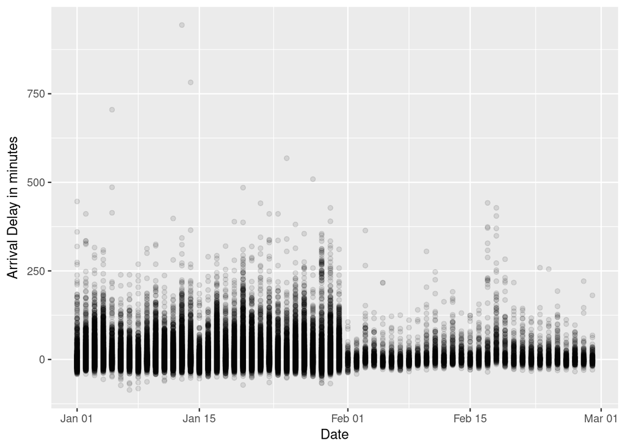

```r
library(ggplot2)
library(dplyr)
ggplot(data = flightDF) +
  geom_point(mapping = aes(x = Date, y = ArrDelay), alpha = 5/50) +
  xlab("Date") +
  ylab("Arrival Delay in minutes")
```

```r
library(stringr)
xtabs(~Origin+Month,flightDF %>%
filter(str_detect(Origin, "^ABE|^ABQ")) %>% droplevels())
```

```
##       Month
## Origin   1   2
##    ABE  93  21
##    ABQ 603   0
```

## Linear models

```r
model <- lm(ArrDelay ~ as.numeric(Date),flightDF)
summary(model)
```

```
##
## Call:
## lm(formula = ArrDelay ~ as.numeric(Date), data = flightDF)
##
## Residuals:
##    Min     1Q Median     3Q    Max
## -92.05 -15.38  -7.54   4.55 937.02
##
## Coefficients:
##                    Estimate Std. Error t value Pr(>|t|)
## (Intercept)      -1.698e+03  9.731e+01  -17.45   <2e-16 ***
## as.numeric(Date)  1.555e-01  8.868e-03   17.53   <2e-16 ***
## ---
## Signif. codes:  0 '***' 0.001 '**' 0.01 '*' 0.05 '.' 0.1 ' ' 1
##
## Residual standard error: 31.19 on 94543 degrees of freedom
##   (5455 observations deleted due to missingness)
## Multiple R-squared:  0.00324,    Adjusted R-squared:  0.00323
## F-statistic: 307.3 on 1 and 94543 DF,  p-value: < 2.2e-16
```

```r
library(broom)
tidy(summary(model))
```

```
##               term      estimate    std.error statistic      p.value
## 1      (Intercept) -1698.2886707 97.313063410 -17.45181 4.266954e-68
## 2 as.numeric(Date)     0.1554628  0.008867835  17.53109 1.066262e-68
```

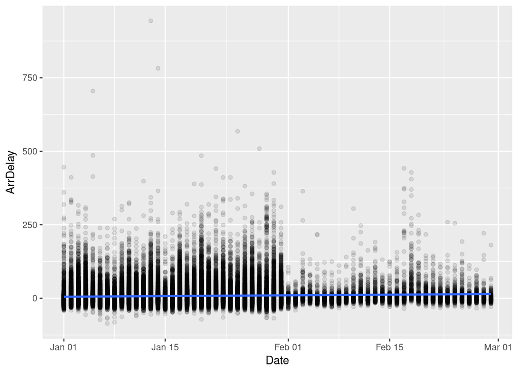

```r
ggplot(flightDF,aes(Date,ArrDelay))+
  geom_point(alpha = 5/50)+
  geom_smooth(method='lm')
```

## Measuring runtime

```r
system.time(gaussianMean<-mean(rnorm(10000)))
```

```
##    user  system elapsed
##   0.000   0.000   0.001
```

```r
 ?proc.time
```

> The first two entries are the total user and system CPU times of the current R process and any child processes on which it has waited, and the third entry is the ‘real’ elapsed time since the process was started.

> The definition of ‘user’ and ‘system’ times is from your OS. Typically it is something like *The ‘user time’ is the CPU time charged for the execution of user instructions of the calling process. The ‘system time’ is the CPU time charged for execution by the system on behalf of the calling process.*

## Read from SQL

```r
library(DBI)
library(RSQLite)
con <- dbConnect(SQLite(), dbname="../data/flight_data/airports.sqlite")
dbReadTable(con, "airport") %>% head
```

```
##   iata              airport             city state country      lat
## 1  00M             Thigpen       Bay Springs    MS     USA 31.95376
## 2  00R Livingston Municipal       Livingston    TX     USA 30.68586
## 3  00V          Meadow Lake Colorado Springs    CO     USA 38.94575
## 4  01G         Perry-Warsaw            Perry    NY     USA 42.74135
## 5  01J     Hilliard Airpark         Hilliard    FL     USA 30.68801
## 6  01M    Tishomingo County          Belmont    MS     USA 34.49167
##         long
## 1  -89.23450
## 2  -95.01793
## 3 -104.56989
## 4  -78.05208
## 5  -81.90594
## 6  -88.20111
```